# Homework 6

Ainesh Mohan

## Problem #1: Estimating Quantiles (8 pts; 2pts each)

There are 9 algorithms in R to estimate population quantiles. Type `?quantile` to read about them. Here we will investigate the variance of some of these estimators. To use the quantile function you use the syntax `quantile(vector, probs, type)`. For example if you have data in a vector called `sampleData` and you wish to estimate the 80th percentile using algorithm 7 (the default), you use `quantile(sampleData, .80, type=7)`

Suppose we’re interested in the 95th percentile for $X$, and we know that $X$ follows a uniform distribution. We want to randomly sample $n=30$ values and estimate the 95th percentile. Using MC simulation estimate the following:

1. Which quantile algorithm (4 through 9 has the smallest absolute bias? *Hint: you can use $unif(0,1)$ for the purposes of this estimation, as your answer won’t depend on the upper and lower bounds chosen.*
2. Which quantile algorithm (4 through 9) has the smallest variance?
3. Which method is best for estimating the 95th percentile from a uniform distribution? Justify your answer.
4. What about if $X\sim N(\mu, \sigma^2)$? Would you prefer a different method for estimating the 95th percentile from a normal distribution? *Hint: repeat the same analysis for $N(0,1)$.*

```r
# Set up the Monte Carlo simulation
set.seed(123)  # for reproducibility
n <- 30  # sample size
N <- 10000  # number of simulations
true_quantile <- 0.95
algorithms <- 4:9
results <- matrix(0, nrow = length(algorithms), ncol = 2, dimnames = list(algorithms, c("Bias", "Variance")))

# Perform the simulation for uniform distribution
for (alg in algorithms) {
  quantiles <- numeric(N)
  for (i in 1:N) {
    sampleData <- runif(n)  # sample from U(0, 1)
    quantiles[i] <- quantile(sampleData, probs = true_quantile, type = alg)
  }
  bias <- mean(quantiles) - true_quantile
  variance <- var(quantiles)
  results[as.character(alg),] <- c(abs(bias), variance)
}

# Display results for uniform distribution
results
```

```
##           Bias    Variance
## 4 0.0299370554 0.001989361
## 5 0.0146047911 0.001838516
## 6 0.0003104199 0.001233745
## 7 0.0288916916 0.001978446
## 8 0.0102529002 0.001639273
## 9 0.0109684056 0.001693450
```

```r
# Perform the simulation for normal distribution
for (alg in algorithms) {
  quantiles <- numeric(N)
  for (i in 1:N) {
    sampleData <- rnorm(n)  # sample from N(0, 1)
    quantiles[i] <- quantile(sampleData, probs = true_quantile, type = alg)
  }
  bias <- mean(quantiles) - qnorm(true_quantile)
  variance <- var(quantiles)
  results[as.character(alg),] <- c(abs(bias), variance)
}

# Display results for normal distribution
results
```

```
##         Bias  Variance
## 4 0.15703005 0.1099037
## 5 0.03828222 0.1361710
## 6 0.16602068 0.1522975
## 7 0.13867333 0.1089265
## 8 0.04037429 0.1355739
## 9 0.01785918 0.1385541
```

## Problem #2: Estimating a Geometric $p$ (6 pts; 2 pts each)

1. Use the method of moments to come up with an estimator for a geometric distributions parameter $p$. *Hint: Use the fact that if $X\sim Geom(p)$ then $EX=\frac{1-p}{p}$.
2. Estimate the sampling distribution of this estimator when we sample $n=13$ values from from $Geom(.15)$. Show the histogram of the estimated sampling distribution.
3. Estimate the bias of this estimator. Is it biased? If it is biased how would you modify it so that you could create an unbiased estimator?

### a. Method of Moments Estimator for Geometric Distribution

The method of moments involves setting the sample mean equal to the theoretical mean and solving for the parameter of interest. For a geometric distribution with parameter $p$, the mean is $E(X) = \frac{1-p}{p}$. We equate this to the sample mean $\bar{x}$ and solve for $p$:

1. Set the theoretical mean equal to the sample mean:
   $$\frac{1-p}{p} = \bar{x}$$
2. Solve for $p$:
   $$1-p = p\bar{x}$$
   $$1 = p\bar{x} + p$$
   $$1 = p(\bar{x} + 1)$$
   $$p = \frac{1}{\bar{x} + 1}$$

Thus, the method of moments estimator for $p$ is $\hat{p} = \frac{1}{\bar{x} + 1}$.

### b. Sampling Distribution of the Estimator

To estimate the sampling distribution of $\hat{p}$ when sampling $n=13$ values from $Geom(0.15)$, we can perform a simulation in R. We will generate many samples of size 13, compute the estimator for each sample, and then plot the histogram of these estimators.

### c. Estimating the Bias of the Estimator

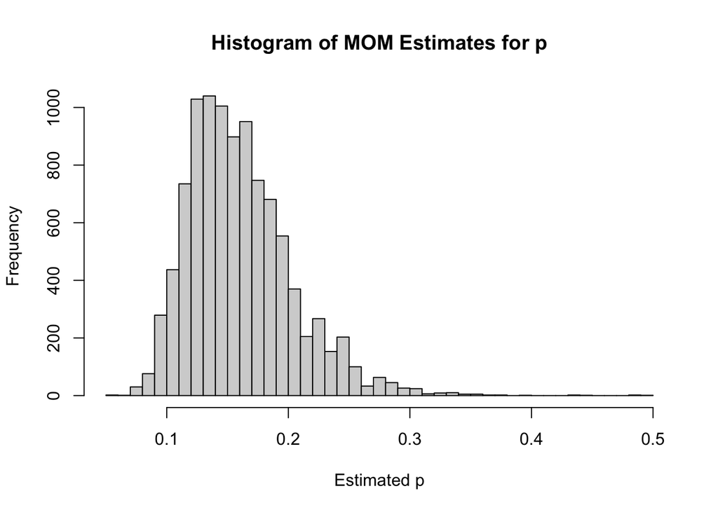

```r
# a. Method of Moments Estimator for Geometric Distribution
# Define the estimator function
mom_estimator <- function(sample) {
  1 / (mean(sample) + 1)
}

# b. Sampling Distribution of the Estimator
# Set parameters for the simulation
n <- 13          # Sample size
p_true <- 0.15   # True value of p
num_samples <- 10000  # Number of samples for the simulation

# Simulate the sampling distribution
set.seed(123)  # For reproducibility
estimates <- replicate(num_samples, mom_estimator(rgeom(n, p_true)))

# Plot the histogram of the estimates
hist(estimates, main = "Histogram of MOM Estimates for p", xlab = "Estimated p", breaks = 40)
```

```r
# c. Estimating the Bias of the Estimator
# Calculate the bias
bias <- mean(estimates) - p_true

# Output the bias
bias
```

```
## [1] 0.01043559
```

## Problem #3: Estimating $\lambda$ from a Poisson Distribution(8 pts; 2 pts each)

It is interesting that if $X\sim Pois(\lambda)$ that $EX=VarX=\lambda$. One could use either $\bar{X}$ or $S^2$ as an estimator of $\lambda$ perhaps.

1. Using $n=15$ and $\lambda=20$ for this problem, use MC simulation to estimate the sampling distribution of The estimator $\bar{X}$. Show its histogram.
2. Repeat the same but this time use $S^2$.
3. Compare the two estimators. Would you prefer one over the other? Why?
4. What about a linear combination of the two variables? Could you construct an estimator of $\lambda$ of the form $a\bar{X} + bS^2$ that would be better than using either of them by themselves?

Let’s address each part of this problem:

### a. Sampling Distribution of $\bar{X}$ as an Estimator for $\lambda$

We will simulate sampling from a Poisson distribution with $\lambda = 20$, calculate $\bar{X}$ for each sample, and then plot the histogram of these sample means.

### b. Sampling Distribution of $S^2$ as an Estimator for $\lambda$

Similarly, we’ll simulate sampling from the same Poisson distribution, calculate the sample variance $S^2$ for each sample, and plot the histogram of these sample variances.

### c. Comparison of the Two Estimators

We’ll compare $\bar{X}$ and $S^2$ in terms of their bias and variance to determine if one might be preferable over the other.

### d. Linear Combination of $\bar{X}$ and $S^2$

We will explore if a linear combination of $\bar{X}$ and $S^2$, say $a\bar{X} + bS^2$, could provide a better estimator for $\lambda$. The coefficients $a$ and $b$ would be chosen to minimize the estimator’s variance while maintaining its unbiasedness.

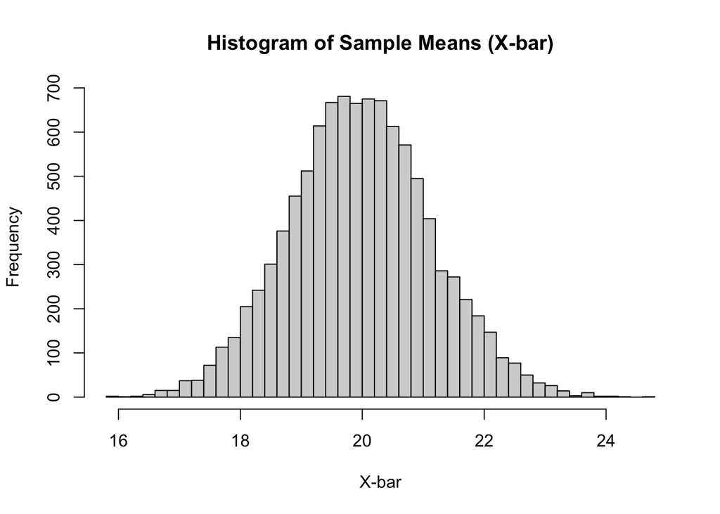

```r
# Parameters for simulation
n <- 15
lambda <- 20
num_samples <- 10000

# a. Sampling Distribution of X-bar
set.seed(123)
sample_means <- replicate(num_samples, mean(rpois(n, lambda)))
hist(sample_means, main = "Histogram of Sample Means (X-bar)", xlab = "X-bar", breaks = 40)
```

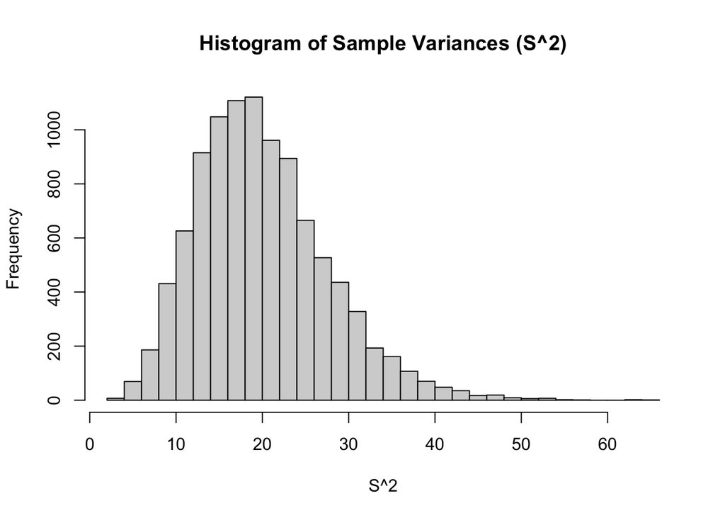

```r
# b. Sampling Distribution of S^2
set.seed(123)
sample_variances <- replicate(num_samples, var(rpois(n, lambda)))
hist(sample_variances, main = "Histogram of Sample Variances (S^2)", xlab = "S^2", breaks = 40)
```

```r
# c. Compare the two estimators
# Calculate the mean and variance of each estimator
mean_xbar <- mean(sample_means)
var_xbar <- var(sample_means)
mean_s2 <- mean(sample_variances)
var_s2 <- var(sample_variances)

# Output the means and variances
mean_xbar
```

```
## [1] 20.00214
```

```r
var_xbar
```

```
## [1] 1.35955
```

```r
mean_s2
```

```
## [1] 20.02039
```

```r
var_s2
```

```
## [1] 57.59083
```

```r
# d. Linear Combination of X-bar and S^2
# For simplicity, consider a = b = 0.5 as an example (not necessarily optimal)
a <- 0.5
b <- 0.5
combined_estimator <- a * sample_means + b * sample_variances
mean_combined <- mean(combined_estimator)
var_combined <- var(combined_estimator)

# Output the mean and variance of the combined estimator
mean_combined
```

```
## [1] 20.01126
```

```r
var_combined
```

```
## [1] 15.40248
```

## Problem #4: The Standard Error of $\bar{X}$(8 pts; 2 pts each)

What would be the required sample size $n$ so that the standard error of $\bar{X}$ (i.e. $SD(\bar{X})$) would be 2 (or just under 2) for the following populations:

1. $\text{Normal}(1000, 10^2)$
2. $\text{Poisson}(75)$
3. $\text{Binomial}(200, .35)$
4. $\text{Exponential}(.05)$

```r
# Standard error target
SE_target <- 2

# a. Normal(1000, 10^2)
sigma_normal <- 10
n_normal <- (sigma_normal / SE_target)^2

# b. Poisson(75)
lambda_poisson <- 75
sigma_poisson <- sqrt(lambda_poisson)
n_poisson <- (sigma_poisson / SE_target)^2
# Since we need an integer number of samples, we round up
n_poisson <- ceiling(n_poisson)

# c. Binomial(200, 0.35)
# Here we use the standard deviation of the binomial distribution to calculate
# the sample size required for the mean's standard error to be under 2.
n_binomial_trial <- 200
p_binomial <- 0.35
sigma_binomial <- sqrt(n_binomial_trial * p_binomial * (1 - p_binomial))
n_binomial <- (sigma_binomial / SE_target)^2
# Adjust for the mean's sample size, not just a single trial
n_binomial <- ceiling(n_binomial)

# d. Exponential(0.05)
lambda_exponential <- 0.05
sigma_exponential <- 1 / lambda_exponential
n_exponential <- (sigma_exponential / SE_target)^2

# Output the results
n_normal
```

```
## [1] 25
```

```r
n_poisson
```

```
## [1] 19
```

```r
n_binomial
```

```
## [1] 12
```

```r
n_exponential
```

```
## [1] 100
```